# Project (Ensemble Technique)

## Objective

The data is related with direct marketing campaigns of a Portuguese banking institution. The marketing campaigns were based on phone calls. Often, more than one contact to the same client was required, in order to access if the product (bank term deposit) would be ('yes') or not ('no') subscribed.

### Context

Leveraging customer information is paramount for most businesses. In the case of a bank, attributes of customers like the ones mentioned below can be crucial in strategizing a marketing campaign when launching a new product.

### Steps:

1. Import the relevant libraries
2. Get the dataset
3. Explore the dataset
4. Pre-processing of dataset
5. Split data into train, test set
6. Build Model, Apply the model & Evaluate the model
7. Provide insights

## Step1. Import Libraries

```python
#Importing pandas library for Data Frame
import pandas as pd

#Importing numpy
import numpy as np

#Importing ploting libraries
import matplotlib.pyplot as plt

#Importing seaborn for statistical plots
import seaborn as sns

#Stats Model
import statsmodels.api as sm
import scipy.stats as stats

#Sklearn package's data splitting function which is based on random function
from sklearn.model_selection import train_test_split

#Sklearn package for decision tree classification
from sklearn.tree import DecisionTreeClassifier

#Sklearn package for random forest classification
from sklearn.ensemble import RandomForestClassifier

#Sklearn package for Gradient Boosting classification
from sklearn.ensemble import GradientBoostingClassifier

#Sklearn package for AdaBoost classification
from sklearn.ensemble import AdaBoostClassifier

#Calculate accuracy measures and confusion matrix
from sklearn import metrics
from sklearn.model_selection import KFold
from sklearn.metrics import classification_report
from sklearn import preprocessing

#Misc
import copy

import warnings
warnings.filterwarnings('ignore')

# To enable plotting graphs in Jupyter notebook
%matplotlib inline
```

## Step2. Get the Dataset

```python
#Loading data frame from CSV file.
df_master = pd.read_csv("bank-full.csv")
df_master.head()
```

|  | age | job | marital | education | default | balance | housing | loan | contact | day | month | duration | campaign | pdays | previous | poutcome | Target |
| --- | --- | --- | --- | --- | --- | --- | --- | --- | --- | --- | --- | --- | --- | --- | --- | --- | --- |
| 0 | 58 | management | married | tertiary | no | 2143 | yes | no | unknown | 5 | may | 261 | 1 | -1 | 0 | unknown | no |
| 1 | 44 | technician | single | secondary | no | 29 | yes | no | unknown | 5 | may | 151 | 1 | -1 | 0 | unknown | no |
| 2 | 33 | entrepreneur | married | secondary | no | 2 | yes | yes | unknown | 5 | may | 76 | 1 | -1 | 0 | unknown | no |
| 3 | 47 | blue-collar | married | unknown | no | 1506 | yes | no | unknown | 5 | may | 92 | 1 | -1 | 0 | unknown | no |
| 4 | 33 | unknown | single | unknown | no | 1 | no | no | unknown | 5 | may | 198 | 1 | -1 | 0 | unknown | no |

## Step3. Exploratory Data Analysis

```python
#Shape of the Data Frame
df_master.shape
```

```
(45211, 17)
```

```python
#Data type of each attribute
df_master.info()
```

```
<class 'pandas.core.frame.DataFrame'>
RangeIndex: 45211 entries, 0 to 45210
Data columns (total 17 columns):
age          45211 non-null int64
job          45211 non-null object
marital      45211 non-null object
education    45211 non-null object
default      45211 non-null object
balance      45211 non-null int64
housing      45211 non-null object
loan         45211 non-null object
contact      45211 non-null object
day          45211 non-null int64
month        45211 non-null object
duration     45211 non-null int64
campaign     45211 non-null int64
pdays        45211 non-null int64
previous     45211 non-null int64
poutcome     45211 non-null object
Target       45211 non-null object
dtypes: int64(7), object(10)
memory usage: 5.9+ MB
```

```python
#Lets find if there are any NaN values in the dataset
df_master[df_master.isnull().any(axis=1)]
```

|  | age | job | marital | education | default | balance | housing | loan | contact | day | month | duration | campaign | pdays | previous | poutcome | Target |
| --- | --- | --- | --- | --- | --- | --- | --- | --- | --- | --- | --- | --- | --- | --- | --- | --- | --- |

#### No Missing Value in the Data Set

```python
#Checking values stored in the dataframe
for column in df_master.columns:
    print("FEATURE NAME & VALUES = %s - %s"%(column, df_master[column].unique()[:15]))
```

```
FEATURE NAME & VALUES = age - [58 44 33 47 35 28 42 43 41 29 53 57 51 45 60]
FEATURE NAME & VALUES = job - ['management' 'technician' 'entrepreneur' 'blue-collar' 'unknown'
 'retired' 'admin.' 'services' 'self-employed' 'unemployed' 'housemaid'
 'student']
FEATURE NAME & VALUES = marital - ['married' 'single' 'divorced']
FEATURE NAME & VALUES = education - ['tertiary' 'secondary' 'unknown' 'primary']
FEATURE NAME & VALUES = default - ['no' 'yes']
FEATURE NAME & VALUES = balance - [2143   29    2 1506    1  231  447  121  593  270  390    6   71  162
  229]
FEATURE NAME & VALUES = housing - ['yes' 'no']
FEATURE NAME & VALUES = loan - ['no' 'yes']
FEATURE NAME & VALUES = contact - ['unknown' 'cellular' 'telephone']
FEATURE NAME & VALUES = day - [ 5  6  7  8  9 12 13 14 15 16 19 20 21 23 26]
FEATURE NAME & VALUES = month - ['may' 'jun' 'jul' 'aug' 'oct' 'nov' 'dec' 'jan' 'feb' 'mar' 'apr' 'sep']
FEATURE NAME & VALUES = duration - [261 151  76  92 198 139 217 380  50  55 222 137 517  71 174]
FEATURE NAME & VALUES = campaign - [ 1  2  3  5  4  6  7  8  9 10 11 12 13 19 14]
FEATURE NAME & VALUES = pdays - [ -1 151 166  91  86 143 147  89 140 176 101 174 170 167 195]
FEATURE NAME & VALUES = previous - [ 0  3  1  4  2 11 16  6  5 10 12  7 18  9 21]
FEATURE NAME & VALUES = poutcome - ['unknown' 'failure' 'other' 'success']
FEATURE NAME & VALUES = Target - ['no' 'yes']
```

### Observations

#### Binary Category Variables:

1. Default - Has credit in default (yes/no).
2. Housing - Has Housing Loan (yes/no).
3. Loan - Has personal loan (yes/no).

#### Ordinal Categorical Variables:

1. Job - Type of job ('management' 'technician' 'entrepreneur' 'blue-collar' 'unknown' 'retired' 'admin.' 'services' 'self-employed' 'unemployed' 'housemaid' 'student').
2. Marital - Marital status ('married' 'single' 'divorced').
3. Education - Education ('tertiary' 'secondary' 'unknown' 'primary').
4. Contact - Contact communication type ('unknown' 'cellular' 'telephone').
5. Month - Last contact month of year ('may' 'jun' 'jul' 'aug' 'oct' 'nov' 'dec' 'jan' 'feb' 'mar' 'apr' 'sep').
6. Poutcome - Outcome of the previous marketing campaign ('unknown' 'failure' 'other' 'success').

#### Interval Variables:

1. Age - Age of the customer?
2. Balance - Average yearly balance, in euros.
3. Day - Last contact day of the month (numeric 1 -31).
4. Duration - Last contact duration, in seconds (numeric). Important note: this attribute highly affects the output target (e.g., if duration=0 then y='no'). Yet, the duration is not known before a call is performed. Also, after the end of the call y is obviously known. Thus, this input should only be included for benchmark purposes and should be discarded if the intention is to have a realistic predictive model.
5. Campaign - Number of contacts performed during this campaign and for this client (numeric, includes last contact)?
6. Pdays - Number of days that passed by after the client was last contacted from a previous campaign (numeric; 999 means client was not previously contacted).
7. Previous - Number of contacts performed before this campaign and for this client.

### Categorical Variables:

We first start the exploratory analysis of the categorical variables and see what are the categories and are there any missing values for these categories. Here, we used the seaborn package to create the bar graphs below.

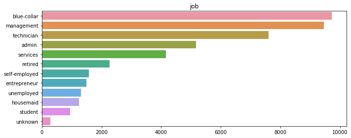

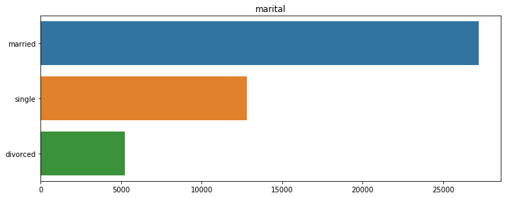

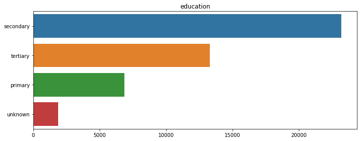

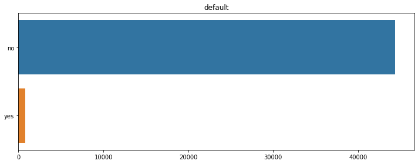

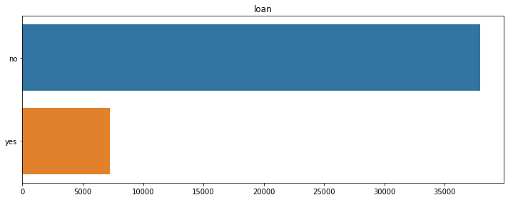

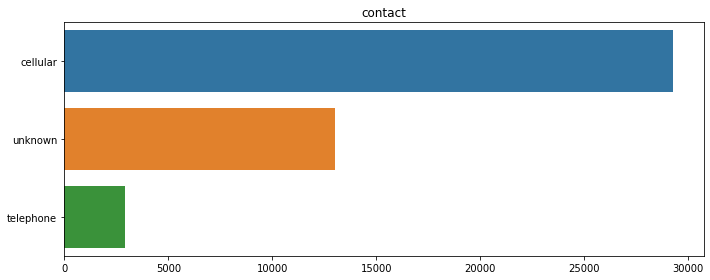

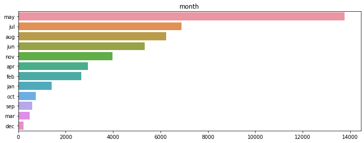

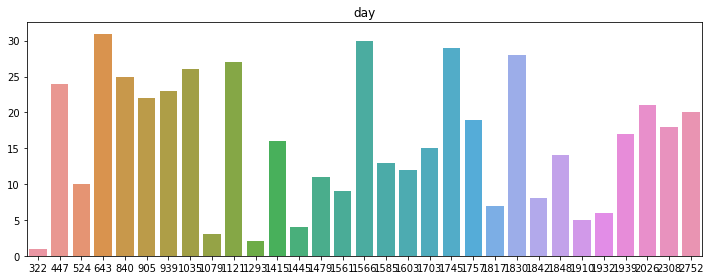

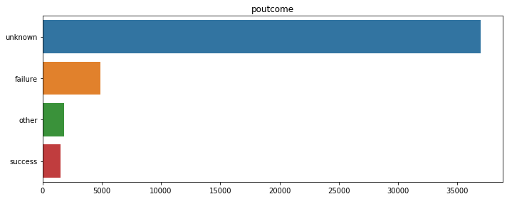

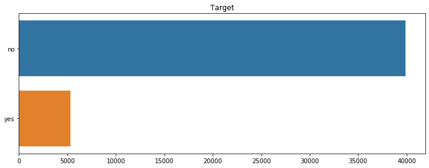

```python
categorcial_variables = ['job', 'marital', 'education', 'default', 'loan', 'contact', 'month', 'day', 'poutcome','Target']
for col in categorcial_variables:
    plt.figure(figsize=(10,4))
    sns.barplot(df_master[col].value_counts().values, df_master[col].value_counts().index)
    plt.title(col)
    plt.tight_layout()
```

#### List of normalized relative frequency of the target class per category.

Normalized distribution of each class per feature and plotted difference between positive and negative frequencies. Positive values imply this category favors clients that will subscribe and negative values categories that favor not buying the product.

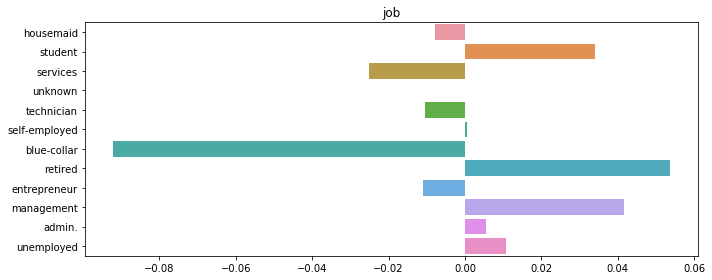

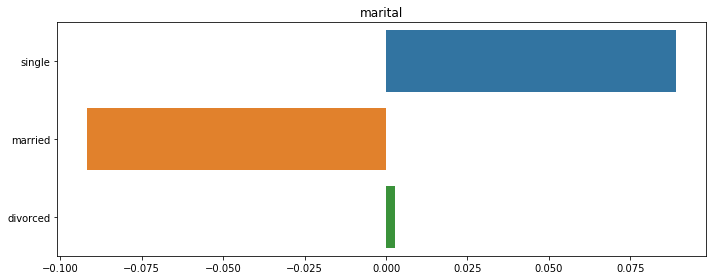

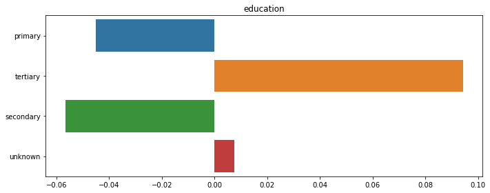

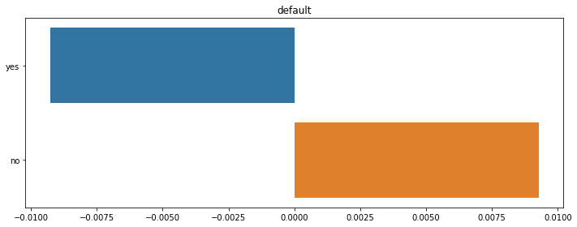

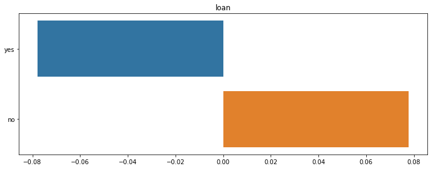

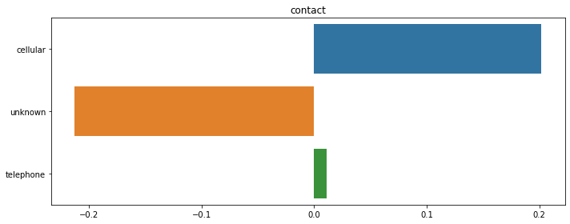

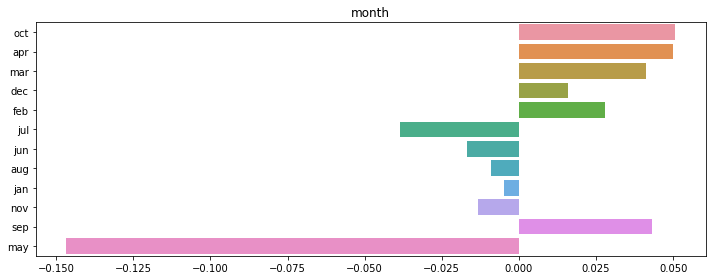

[figure not shown]

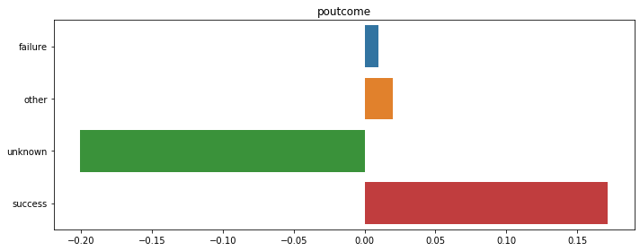

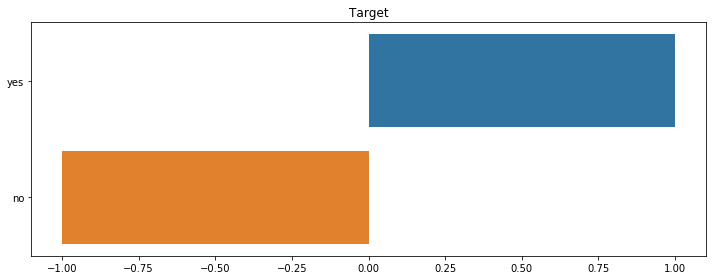

```python
for col in categorcial_variables:
    plt.figure(figsize=(10,4))
    #Returns counts of unique values for each outcome for each feature.
    pos_counts = df_master.loc[df_master.Target.values == 'yes', col].value_counts()
    neg_counts = df_master.loc[df_master.Target.values == 'no', col].value_counts()

    all_counts = list(set(list(pos_counts.index) + list(neg_counts.index)))

    #Counts of how often each outcome was recorded.
    freq_pos = (df_master.Target.values == 'yes').sum()
    freq_neg = (df_master.Target.values == 'no').sum()

    pos_counts = pos_counts.to_dict()
    neg_counts = neg_counts.to_dict()

    all_index = list(all_counts)
    all_counts = [pos_counts.get(k, 0) / freq_pos - neg_counts.get(k, 0) / freq_neg for k in all_counts]

    sns.barplot(all_counts, all_index)
    plt.title(col)
    plt.tight_layout()
```

#### Inference/Result:

There are unknown values for many variables in the Data set. There are many ways to handle missing data. One of the ways is to discard the row but that would lead to reduction of data set and hence would not serve our purpose of building an accurate and realistic prediction model.

Other method is to smartly infer the value of the unknown variable from the other variables. This a way of doing an imputation where we use other independent variables to infer the value of the missing variable. This doesn't gurantee that all missing values will be addressed but majority of them will have a reasonable which can be useful in the prediction.

Variables with unknown/missing values are : 'education', 'job', 'contact' and 'poutcome'. But the significant ones are 'education' and 'job'.

#### Imputation:

Now, to infer the missing values in 'job' and 'education', we make use of the cross-tabulation between 'job' and 'education'. Our hypothesis here is that 'job' is influenced by the 'education' of a person. Hence, we can infer 'job' based on the education of the person. Moreover, since we are just filling the missing values, we are not much concerned about the causal inference. We, therefore, can use the job to predict the education.

## Step4. Pre-processing of dataset

```python
def cross_tab(df,f1,f2):
    jobs=list(df[f1].unique())
    edu=list(df[f2].unique())
    dataframes=[]
    for e in edu:
        dfe=df[df[f2]==e]
        dfejob=dfe.groupby(f1).count()[f2]
        dataframes.append(dfejob)
    xx=pd.concat(dataframes,axis=1)
    xx.columns=edu
    xx=xx.fillna(0)
    return xx
```

```python
cross_tab(df_master,'job','education')
```

| job | tertiary | secondary | unknown | primary |
| --- | --- | --- | --- | --- |
| admin. | 572 | 4219 | 171 | 209 |
| blue-collar | 149 | 5371 | 454 | 3758 |
| entrepreneur | 686 | 542 | 76 | 183 |
| housemaid | 173 | 395 | 45 | 627 |
| management | 7801 | 1121 | 242 | 294 |
| retired | 366 | 984 | 119 | 795 |
| self-employed | 833 | 577 | 39 | 130 |
| services | 202 | 3457 | 150 | 345 |
| student | 223 | 508 | 163 | 44 |
| technician | 1968 | 5229 | 242 | 158 |
| unemployed | 289 | 728 | 29 | 257 |
| unknown | 39 | 71 | 127 | 51 |

```python
df_master['job'][df_master['age']>60].value_counts()
```

```
retired          875
management       105
housemaid         56
technician        30
blue-collar       26
admin.            25
self-employed     24
unknown           22
entrepreneur      13
unemployed        10
services           2
Name: job, dtype: int64
```

Inferring education from jobs : From the cross-tabulation, it can be seen that people with management jobs usually have a tertiary degree. Hence wherever 'job' = management and 'education' = unknown, we can replace 'education' with 'tertiary'. Similarly, 'job' = 'services' --> 'education' = 'secondary' and 'job' = 'admin.' --> 'education' = 'secondary'.

Inferring jobs from education : If 'education' = 'primary' then the 'job' is usually 'blue-collar'. If 'education' = 'tertiary', then the 'job' = 'management'.

Inferring jobs from age: As we see, if 'age' > 60, then the 'job' is 'retired,' which makes sense.

While imputing the values for job and education, we were cognizant of the fact that the correlations should make real world sense. If it didn't make real world sense, we didn't replace the missing values.

```python
df_master.loc[(df_master['age']>60) & (df_master['job']=='unknown'), 'job'] = 'retired'
df_master.loc[(df_master['education']=='unknown') & (df_master['job']=='management'), 'education'] = 'tertiary'
df_master.loc[(df_master['education']=='unknown') & (df_master['job']=='services'), 'education'] = 'secondary'
df_master.loc[(df_master['education']=='unknown') & (df_master['job']=='admin.'), 'education'] = 'secondary'
df_master.loc[(df_master['education']=='unknown') & (df_master['job']=='housemaid'), 'education'] = 'primary'
df_master.loc[(df_master['job']=='unknown') & (df_master['education']=='tertiary'), 'job'] = 'management'
df_master.loc[(df_master['job']=='unknown') & (df_master['education']=='primary'), 'job'] = 'blue-collar'
```

```python
cross_tab(df_master,'contact','poutcome')
```

| contact | unknown | failure | other | success |
| --- | --- | --- | --- | --- |
| cellular | 21734 | 4529 | 1637 | 1385 |
| telephone | 2275 | 341 | 176 | 114 |
| unknown | 12950 | 31 | 27 | 12 |

```python
df_master.loc[(df_master['poutcome']=='failure') & (df_master['contact']=='unknown'), 'contact'] = 'cellular'
df_master.loc[(df_master['poutcome']=='other') & (df_master['contact']=='unknown'), 'contact'] = 'cellular'
df_master.loc[(df_master['poutcome']=='success') & (df_master['contact']=='unknown'), 'contact'] = 'cellular'
```

### Numerical variables:

Let see the summary of the data in order to understand the numerical variables.

```python
df_master.describe().T
```

|  | count | mean | std | min | 25% | 50% | 75% | max |
| --- | --- | --- | --- | --- | --- | --- | --- | --- |
| age | 45211.0 | 40.936210 | 10.618762 | 18.0 | 33.0 | 39.0 | 48.0 | 95.0 |
| balance | 45211.0 | 1362.272058 | 3044.765829 | -8019.0 | 72.0 | 448.0 | 1428.0 | 102127.0 |
| day | 45211.0 | 15.806419 | 8.322476 | 1.0 | 8.0 | 16.0 | 21.0 | 31.0 |
| duration | 45211.0 | 258.163080 | 257.527812 | 0.0 | 103.0 | 180.0 | 319.0 | 4918.0 |
| campaign | 45211.0 | 2.763841 | 3.098021 | 1.0 | 1.0 | 2.0 | 3.0 | 63.0 |
| pdays | 45211.0 | 40.197828 | 100.128746 | -1.0 | -1.0 | -1.0 | -1.0 | 871.0 |
| previous | 45211.0 | 0.580323 | 2.303441 | 0.0 | 0.0 | 0.0 | 0.0 | 275.0 |

```python
pd.crosstab(df_master['pdays'], df_master['poutcome'])[0:1]
```

| poutcome pdays | failure | other | success | unknown |
| --- | --- | --- | --- | --- |
| -1 | 0 | 0 | 0 | 36954 |

```python
pd.crosstab(df_master['pdays'], df_master['previous'])[0:1]
```

| previous pdays | 0 | 1 | 2 | 3 | 4 | 5 | 6 | 7 | 8 | 9 | ... | 32 | 35 | 37 | 38 | 40 | 41 | 51 | 55 | 58 | 275 |
| --- | --- | --- | --- | --- | --- | --- | --- | --- | --- | --- | --- | --- | --- | --- | --- | --- | --- | --- | --- | --- | --- |
| -1 | 36954 | 0 | 0 | 0 | 0 | 0 | 0 | 0 | 0 | 0 | ... | 0 | 0 | 0 | 0 | 0 | 0 | 0 | 0 | 0 | 0 |

1 rows × 41 columns

From the source of the data, we're told that 999 or -1 means client was not previously contacted.

Outliers: Outliers are defined as 1.5 x Q3 value (75th percentile).

```
           Q3     1.5*Q3
age        48         72
balance  1428       2142
day        21        31.5
duration  319       478.5
campaign    3         4.5
pdays      -1        -1.5
previous    0         0
```

From the above table, it can be seen that alomost every column have outliers.

But we also see that the value of these outliers are not so unrealistic (max('age')=95 and max('campaign')=63). Hence, we need not remove them since the prediction model should represent the real world. This improves the generalizability of the model and makes it robust for real world situations. The outliers, therefore, are not removed.

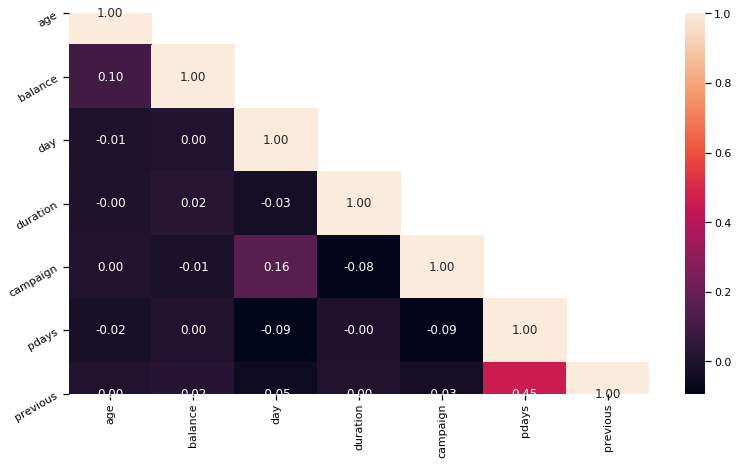

```python
#Graphical representation of correlations between features
corr = df_master.corr()
sns.set_context("notebook", font_scale=1.0, rc={"lines.linewidth": 2.5})
plt.figure(figsize=(13,7))
mask = np.zeros_like(corr)
mask[np.triu_indices_from(mask, 1)] = True
a = sns.heatmap(corr,mask=mask, annot=True, fmt='.2f')
rotx = a.set_xticklabels(a.get_xticklabels(), rotation=90)
roty = a.set_yticklabels(a.get_yticklabels(), rotation=30)
```

#### Observation

```python
df_with_dummies=pd.get_dummies(df_master)
```

```python
def drawheatmap(df):
    '''Builds the heat map for the given data'''
    f, ax = plt.subplots(figsize=(15, 15))
    sns.heatmap(df.corr(method='spearman'), annot=False, cmap='coolwarm')
```

```python
def dropfeature(df,f):
    """Drops one of the dummy variables."""
    df=df.drop(f,axis=1)
    return df

features_dropped = ['default_no','housing_no','loan_no','Target_no','marital_single','contact_cellular',
                    'education_unknown','job_unknown']

df_clean = dropfeature(df_with_dummies, features_dropped)
```

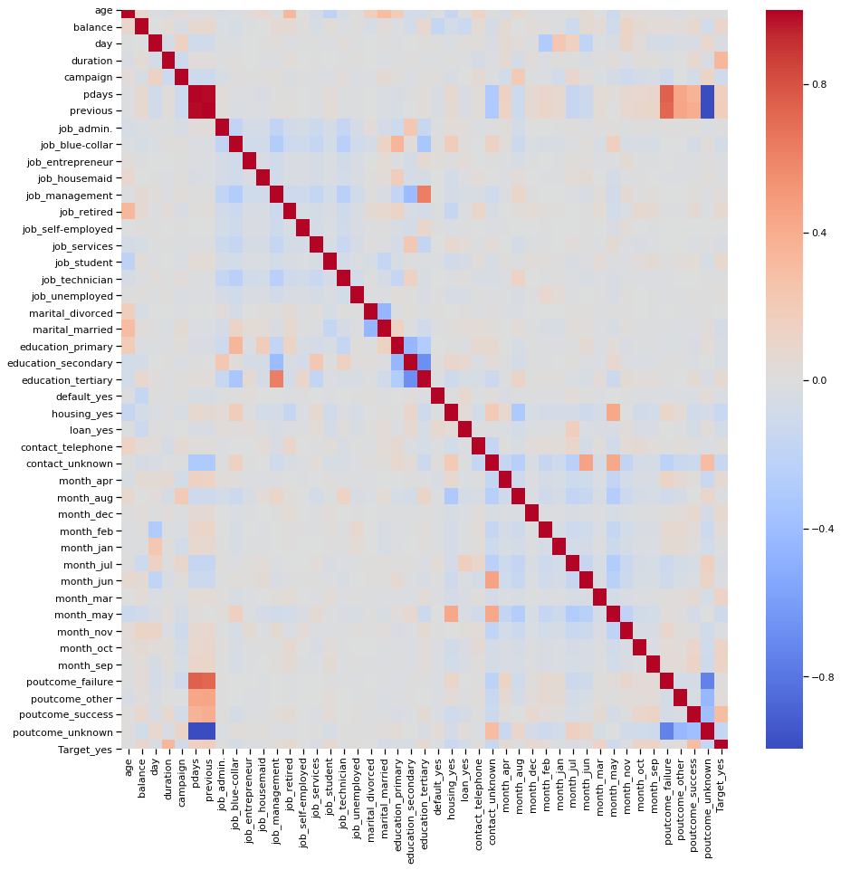

```python
drawheatmap(df_clean)
```

## Step5. Split data into train, test set

Train Test Split : First we start with splitting the data into training and testing. For all the models, five-fold cross validation will be used.

```python
train, test = train_test_split(df_clean, train_size=0.8, random_state=5)
print('Original:', (df_clean.Target_yes).mean(), 'Train:', (train.Target_yes).mean(), 'Test:', (test.Target_yes).mean())

train, test = train_test_split(df_clean, train_size=0.8, stratify=df_clean.Target_yes.values, random_state=5)
print('Original:', (df_clean.Target_yes).mean(), 'Train:', (train.Target_yes).mean(), 'Test:', (test.Target_yes).mean())
```

```
Original: 0.11698480458295547 Train: 0.11731364742313648 Test: 0.11566957867964171
Original: 0.11698480458295547 Train: 0.11698186241981863 Test: 0.11699657193409267
```

## Step6. Build Model

#### Common Functions for Reusability

```python
def getmeanauc(aucs, model):
    ''' Calculates the mean AUC for all the cross-validated samples and computes the value of C (Regularization Parameter)
    for which max mean auc is obtained'''
    #Initialize empty array to hold mean AUC values.
    meanauc = []
    maxmean = 0 #Initial value for maximum mean AUC
    models_with_1_param = ['Ada_Boost']
    models_with_2_params = ['Decision_Tree' , 'Random_Forest', 'Grad_Boost']
    for c in aucs: #For loop to append AUC value to meanauc array.
        meanauc.append(np.mean(aucs[c]))
        if maxmean < np.mean(aucs[c]):
            maxmean = np.mean(aucs[c]) #Adjust value of maxmean
            cval = c
    if model in models_with_1_param:
        print("C value for max auc is: ",cval)
        print("Max Mean Auc corresponding to the optimal value of C = ", maxmean)
        return meanauc,cval
    if model in models_with_2_params:
        listSL=cval.split('L')
        splitval=int(listSL[0]) #Stores minimum split value for max AUC
        leafval=int(listSL[1]) #Stores minimum leaf value for max AUC
        print("min_sample_split value for max auc is:",splitval)
        print("min_sample_leaf value for max auc is:",leafval)
        print("Max mean AUC corresponding to optimal leaf and split value = ",maxmean)
        return meanauc,splitval,leafval

def plot_mean_auc_LR(aucs,cs, label):
    '''Plots different values of mean auc versus the hyperparameter C'''
    plt.plot(np.log10(cs),aucs, label = label )
    plt.xlabel("C (Regularization Parameter)")
    plt.ylabel("Mean AUC")
    plt.legend()

def plotfeatureimportances(train, importance):
    '''Plots feature importance in a sorted order and shows the most significant variables at the top'''
    X = list(train.columns)
    X.remove('Target_yes')
    feature_importance_df = pd.DataFrame(data = importance, index = X, columns=['coefficient_values'])
    feature_importance_df['sort'] = feature_importance_df.coefficient_values.abs()
    sorted_feature_imp_df = feature_importance_df.sort_values(by='sort', ascending=False).drop('sort', axis=1)
    fig, ax = plt.subplots()
    fig.set_size_inches(10, 15)
    sns.barplot(np.array(sorted_feature_imp_df.coefficient_values), np.array(sorted_feature_imp_df.index.values))
    plt.title('Feature Importances')
    plt.xlabel('Coefficients')
    plt.ylabel('Feature Names')

def plotfeatureimp(fl,col):
    '''Plots the feature importance of all the independent variables in the model'''
    f=plt.figure(figsize=(10,15))
    plt.barh(range(len(fl)),fl)
    plt.yticks(range(len(col[:-1])),col[:-1])

def plotAUCDTRF(aucs,leafs,splits):
    '''Plots AUC for each value of Leaf and Split combination'''
    for i in range(len(splits)):
        plt.plot(leafs,aucs[len(leafs)*i:len(leafs)*i+len(leafs)], label = 'Split value= ' + str(splits[i]))
    plt.legend()
    plt.xlabel('Leaf Values')
    plt.ylabel('Mean AUC')

def plot_mean_auc_Ada_Boost(aucs, estimators, label):
    '''Plots different values of mean auc versus the Estimators for AdaBoosting'''
    plt.plot(estimators,aucs, label = label )
    plt.xlabel("Estimators")
    plt.ylabel("Mean AUC")
    plt.legend()
```

### Decision Tree Model Function

```python
def DTmodel(train, validation, leaf=1, split=2):
    X=list(train.columns) #Create list of column labels from training data
    Y='Target_yes'
    X.remove('Target_yes')
    xtrain=train[X]
    ytrain=train[Y]
    xval=validation[X]
    yval=validation[Y]

    #Runs sklearn's decision tree algorithm on the training data with min leaf size 1 and split size 2
    dt=DecisionTreeClassifier(criterion='entropy',min_samples_leaf=leaf,min_samples_split=split)

    #Train the model
    dt.fit(xtrain,ytrain)
    predict_proba_val=dt.predict_proba(xval)[:,1] #Predict class probabilities of input validation data
    auc=metrics.roc_auc_score(yval,predict_proba_val) #Compute ROC AUC from prediction scores
    fpr,tpr,threshold=metrics.roc_curve(yval,predict_proba_val) #Compute ROC
    accuracy=metrics.accuracy_score(yval,dt.predict(xval)) #Compute subset accuracy classification score

    #Feature importances. The higher the score, the more important the feature.
    #Computed as the normalized total reduction of the criterion brought by that feature.
    imp=dt.feature_importances_
    return auc,imp,tpr,fpr,threshold,accuracy
```

### Cross Validation and Hyper Parameter Tuning for Decision Tree

```python
def kfoldDTRF(dataset, k, split, leaf, model):
    aucs={}
    kf=KFold(n_splits=k) #Provides indices to split data in train/test sets
    for train_idx, vali_idx in kf.split(dataset):
        cv_train, cv_validate=dataset.iloc[train_idx,:], dataset.iloc[vali_idx,:]
        for sp in split:
            for lf in leaf:
                if model=='DT':
                    #Run decision tree function above based on user input
                    core,fimp,tpr,fpr,threshold,accuracy=DTmodel(cv_train,cv_validate,lf,sp)
                if model=='RF':
                    #Run random forest function below based on user input
                    core,fimp,tpr,fpr,threshold,accuracy=randomforrest(cv_train,cv_validate,lf,sp)

                if str(sp)+"L"+str(lf) in aucs:
                    aucs[str(sp)+"L"+str(lf)].append(core)
                else:
                    aucs[str(sp)+"L"+str(lf)]=[]
                    aucs[str(sp)+"L"+str(lf)].append(core)
    return aucs
```

min_sample_split_value and min_sample_leaf are hyper paremeters for Decision Tree and Random Forest indicating minimum split size and minimum leaf size. The range of value taken for split is [10,2000] and the range for leaf is [5,200]. Hence, there are 100 combination of split and leaf values. For each of these combinations, the AUC is calculated.

```python
split = np.geomspace(10, 2000, num=10, dtype=int)
leaf = np.geomspace(5, 200, num=10, dtype=int)
aucsdt=kfoldDTRF(train, 5, split, leaf,'DT')
```

```
min_sample_split value for max auc is: 341
min_sample_leaf value for max auc is: 17
Max mean AUC corresponding to optimal leaf and split value =  0.9126363435388555
```

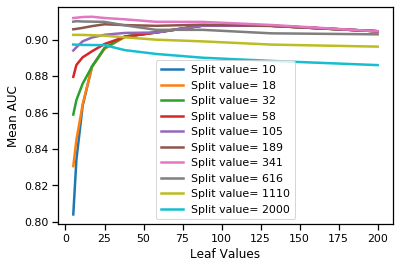

```python
meanauc, splitval, leafval=getmeanauc(aucsdt,'Decision_Tree')
plotAUCDTRF(meanauc, leaf, split)
```

### Random Forest Model

```python
def randomforrest(train, validation, leaf=1, split=2):
    '''Random Forest model to fit the training set to random forest and compute AUC on test/validation set'''
    X=list(train.columns) #Provides indices to split data in train/test sets
    Y='Target_yes'
    X.remove('Target_yes')
    xtrain=train[X]
    ytrain=train[Y]
    xval=validation[X]
    yval=validation[Y]

    #Run sklearn's random forest algorithm with 128 trees and a minimum split size of 2 and minimum leaf size 1
    random_forest = RandomForestClassifier(n_estimators=128,min_samples_split=split,min_samples_leaf=leaf)

    #Train the model
    random_forest.fit(xtrain,ytrain)

    #Predict target values
    Y_pred = random_forest.predict(xval)

    #Predict class probabilities of input validation data
    proba_val=random_forest.predict_proba(xval)[:,1]

    #Compute ROC
    fpr, tpr, thresholds=metrics.roc_curve(yval,proba_val)

    #Compute ROC AUC scores from prediction values
    score=metrics.roc_auc_score(yval,proba_val)

    #Feature importances. The higher the score, the more important the feature.
    #Computed as the normalized total reduction of the criterion brought by that feature.
    importance=random_forest.feature_importances_
    accuracy=metrics.accuracy_score(yval,random_forest.predict(xval))
    return score,importance,tpr,fpr,thresholds,accuracy
```

### Cross Validation and Hyper Parameter Tuning for Random Forest

min_sample_split_value and min_sample_leaf are hyper parameters for random forest indicating minimum split size and minimum leaf size. The range of value taken for split is [10,2000] and the range for leaf is [5,200]. hence, there are 100 combination of split and leaf values. For each of these combinations, the AUC is calculated.

```python
RF_split = np.geomspace(10, 2000, num=10, dtype=int)
RF_leaf = np.geomspace(5, 200, num=10, dtype=int)

RF_auc=kfoldDTRF(train, 5, RF_split, RF_leaf, 'RF')
```

```
min_sample_split value for max auc is: 18
min_sample_leaf value for max auc is: 5
Max mean AUC corresponding to optimal leaf and split value =  0.9308757614186124
```

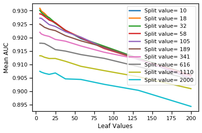

```python
RF_aucs,RF_splitval,RF_leafval=getmeanauc(RF_auc, 'Random_Forest')
plotAUCDTRF(RF_aucs,RF_leaf,RF_split)
```

#### Inference: It's evident that Random Forest is performing better than Decision Tree models.

### Gradient Boosting Model

```python
def GBoosting(train,validation,leaf=1,split=2):
    """Function for gradient boosting to minimize loss via weak learners"""
    X=list(train.columns)
    Y='Target_yes'
    X.remove('Target_yes')
    xtrain=train[X]
    ytrain=train[Y]
    xval=validation[X]
    yval=validation[Y]

    GB = GradientBoostingClassifier(min_samples_split=split, min_samples_leaf=leaf)

    #Train the model
    GB.fit(xtrain,ytrain)

    #Predict target values
    Y_pred = GB.predict(xval)

    #Predict class probabilities of input validation data
    gbplot=GB.predict_proba(xval)
    gbpre=gbplot[:,1]

    #Compute ROC
    gbfpr, gbtpr, gbthresholds=metrics.roc_curve(yval,gbpre)

    #Compute ROC AUC scores from prediction values
    gbscore=metrics.roc_auc_score(yval,gbpre)
    gbaccuracy=metrics.accuracy_score(yval,GB.predict(xval))

    #Feature importances. The higher the score, the more important the feature.
    importance=GB.feature_importances_

    return gbscore,importance,gbtpr,gbfpr,gbthresholds,gbaccuracy
```

### Cross Validation and Hyper Paremeter Tuning for Gradient Boosting

```python
def kfoldGB(dataset, k, split, leaf):
    aucs={}
    kf=KFold(n_splits=k) #Provides indices to split data in train/test sets
    for sp in split:
        for lf in leaf:
            for train_idx, vali_idx in kf.split(dataset):
                cv_train,cv_validate=dataset.iloc[train_idx,:], dataset.iloc[vali_idx,:]
                #Run Gradient Boosted Trees function defined above based on user input
                gbscore,importance,gbtpr,gbfpr,gbthresholds,gbaccuracy= GBoosting(cv_train,cv_validate,lf,sp)

                #Storing the AUC scores in the aucs dictionary for all split values (sp) and leaf values (lf)
                if str(sp)+"L"+str(lf) in aucs:
                    aucs[str(sp)+"L"+str(lf)].append(gbscore)
                else:
                    aucs[str(sp)+"L"+str(lf)]=[]
                    aucs[str(sp)+"L"+str(lf)].append(gbscore)
    return aucs
```

```python
gbsplit = np.geomspace(10, 1500, num=8, dtype=int)
gbleaf = np.geomspace(5, 750, num=6, dtype=int)
gbaucs = kfoldGB(train, 5, gbsplit, gbleaf)
```

```
min_sample_split value for max auc is: 10
min_sample_leaf value for max auc is: 13
Max mean AUC corresponding to optimal leaf and split value =  0.9257523133827883
```

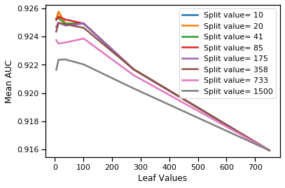

```python
gbauc, gbsplitval, gbleafval=getmeanauc(gbaucs,'Grad_Boost')
plotAUCDTRF(gbauc,gbleaf,gbsplit)
```

#### Inference: We see from the above output that Gradient Boosting performs better than Decision Tree but inferior to Random Forest.

```python
def adaboost(settrain, settest, nestimator = 100):
    X=list(settrain.columns)
    Y='Target_yes'
    X.remove('Target_yes')
    xtrain=settrain[X]
    ytrain=settrain[Y]
    xtest=settest[X]
    ytest=settest[Y]
    #Instantiate a Decision Stump
    dt_stump = DecisionTreeClassifier(max_depth=1, min_samples_leaf=1)

    #Instantitate an AdaBoostClassifier using the decision stump defined above
    ad = AdaBoostClassifier(base_estimator=dt_stump, n_estimators=nestimator)

    #fit the AdaBoostClassifier on the training data
    ad.fit(xtrain,ytrain)

    #Predict the Y values for the test/validation data
    Y_pred = ad.predict(xtest)

    #Predict class probabilities of input validation data
    adplot=ad.predict_proba(xtest)

    adpre=adplot[:,1]

    #Computation to compute AUC score
    adfpr, adtpr, adthresholds=metrics.roc_curve(ytest,adpre)
    adscore=metrics.roc_auc_score(ytest,adpre)

    #Feature importances. The higher the score, the more important the feature.
    ii=ad.feature_importances_
    return adscore,ii
```

### Cross Validation and Hyper Parameter Tuning for Adaboost Model

```python
def kfoldadaboost(dataset, k, estimators):
    aucs ={}
    kf=KFold(n_splits=k) #Provides indices to split data in train/test sets
    for e in estimators:
        for train_idx, vali_idx in kf.split(dataset):
            cv_train,cv_validate=dataset.iloc[train_idx,:], dataset.iloc[vali_idx,:]

            #Run AdaBoostClassifier function defined above based on user input
            core,f= adaboost(cv_train,cv_validate, nestimator = e)

            #storing the auc Scores in the aucs dictionary for all the estimator values.
            aucs[e] = []
            aucs[e].append(core)
    return aucs
```

For Adaboost, n_estimators is the hyper parameter which corresponds to maximum number of estimators. we are taking the range of values (50,2000) to see which of these values gives highest AUC when Adaboost is used

```python
estimators = np.array([50,100,400,600,1000,2000])
adaauc = kfoldadaboost(train, 5, estimators)
```

```
C value for max auc is:  100
Max Mean Auc corresponding to the optimal value of C =  0.9189145137927107
```

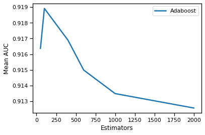

```python
adaaucs,adac=getmeanauc(adaauc,'Ada_Boost')
plot_mean_auc_Ada_Boost(adaaucs,estimators,'Adaboost')
```

#### Inference: We see from the above output that Ada Boost performs better than Decision Tree but inferior to Gradiant Boosting and Random Forest.

## Step7. Provide Insights

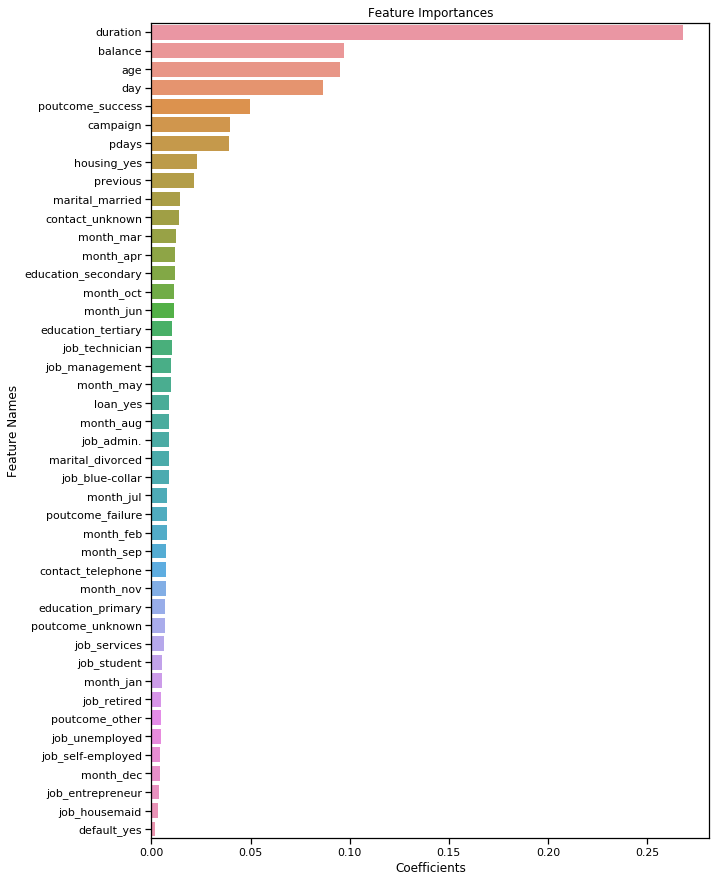

```python
score,importance,tpr,fpr,thresholds,accuracy=randomforrest(train,test)
plotfeatureimportances(train, importance)
```

```python
print('Final Test AUC Score = ', score)
```

```
Final Test AUC Score =  0.9338263615735081
```